# **Panorama da inflação**

Os principais índices de inflação do Brasil, apontam em agosto de 2020 um avanço da inflação de em média **1.11%**. Com esse resultado, no ano a inflação acumula uma variação média positiva de **3.66%**, e em 12 meses uma variação média acumulada de **6.13%**.

[output not shown]

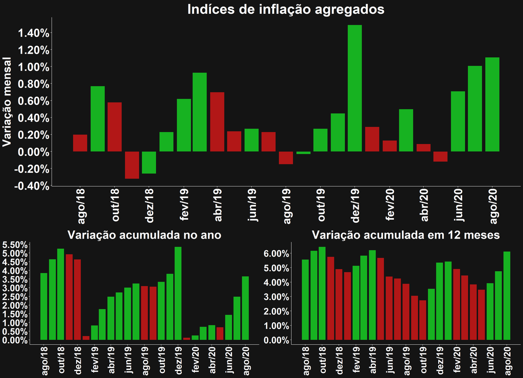

Índices selecionados para a média: IPCA, INPC e IGP-M.

# IPCA

O Indíce de Preços ao Consumidor Amplo (IPCA) variou 0.24% em agosto, valor superior ao mesmo período do ano anterior quando apresentou uma taxa de 0.11%. Com esse resultado o indíce acumula no ano uma variação positiva de 0.7%, e em 12 meses uma variação positiva de 2.44%.

|  | 08/2019 | 07/2020 | 08/2020 |
| --- | --- | --- | --- |
| Variação mensal | 0.11% | 0.36% | 0.24% |
| Variação acumulada no ano | 2.54% | 0.46% | 0.7% |
| Variação acumulada em 12 meses | 3.43% | 2.31% | 2.44% |

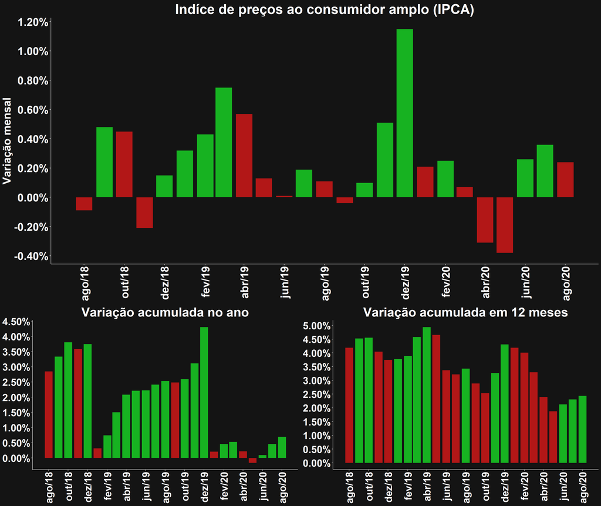

Os grupos que tiveram maior resultado positivo foram Transportes (0.82%) e Alimentação e bebidas (0.78%), e negativo Educação (-3.47%) e Vestuário (-0.78%).

|  | Variação mensal | Variação acumulada no ano | Peso mensal |
| --- | --- | --- | --- |
| Alimentação e bebidas | 0.78% | 4.92% | 20.05% |
| Habitação | 0.36% | 1.14% | 15.64% |
| Artigos de residência | 0.56% | 0.71% | 3.74% |
| Vestuário | -0.78% | -3.2% | 4.44% |
| Transportes | 0.82% | -3.46% | 19.64% |
| Saúde e cuidados pessoais | 0.5% | 1.6% | 13.62% |
| Despesas pessoais | -0.01% | 0.08% | 10.7% |
| Educação | -3.47% | 0.8% | 6.39% |
| Comunicação | 0.67% | 2.36% | 5.78% |

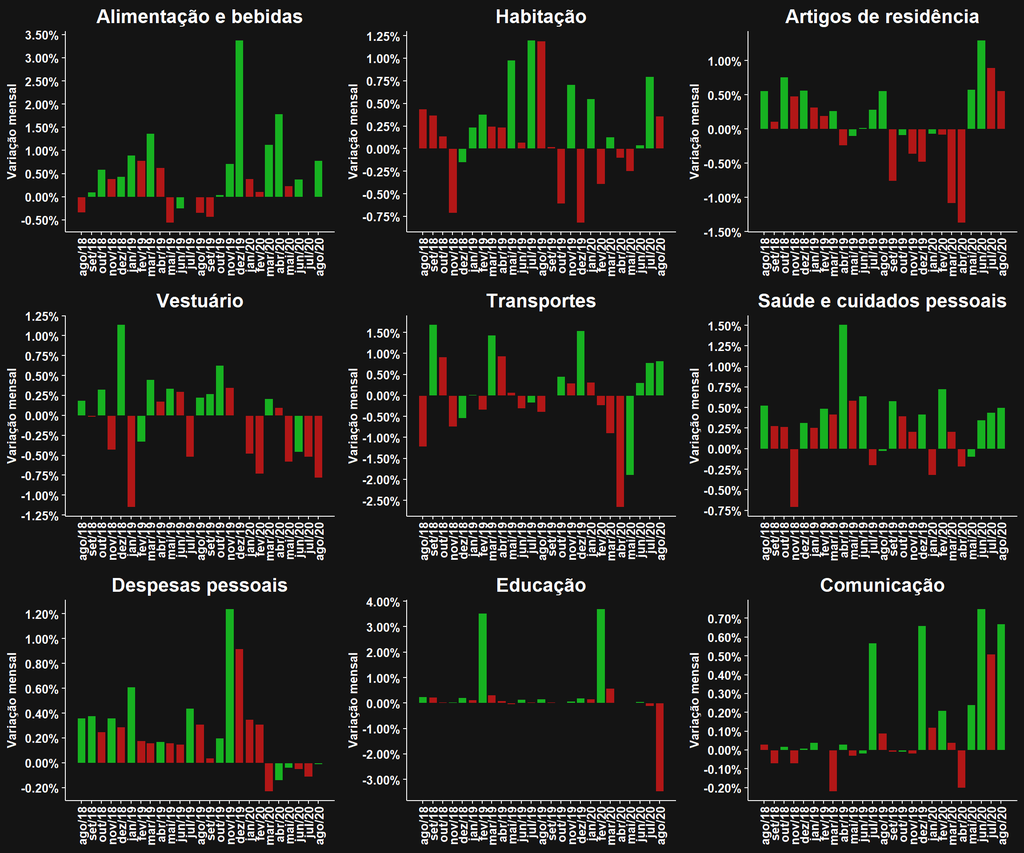

A nível de sub-itens os que mais influenciaram positivamente no resultado em relação ao seu peso foram Gasolina (3.22%%) e Acesso à internet (8.51%%), e negativamente Ensino superior (-4.12%%) e Ensino fundamental (-4.12%%).

|  | Variação mensal | Variação acumulada no ano | Peso mensal |
| --- | --- | --- | --- |
| Acesso à internet | 8.51% | 8.51% | 0.55% |
| Leite longa vida | 4.84% | 23% | 0.72% |
| Gasolina | 3.22% | -5.92% | 4.67% |
| Plano de saúde | 0.6% | 4.89% | 4.17% |

|  | Variação mensal | Variação acumulada no ano | Peso mensal |
| --- | --- | --- | --- |
| Cebola | -17.18% | 50.39% | 0.19% |
| Ensino superior | -4.12% | -0.91% | 1.92% |
| Ensino fundamental | -4.12% | 2.86% | 1.59% |
| Pré-escola | -7.71% | -1.73% | 0.34% |

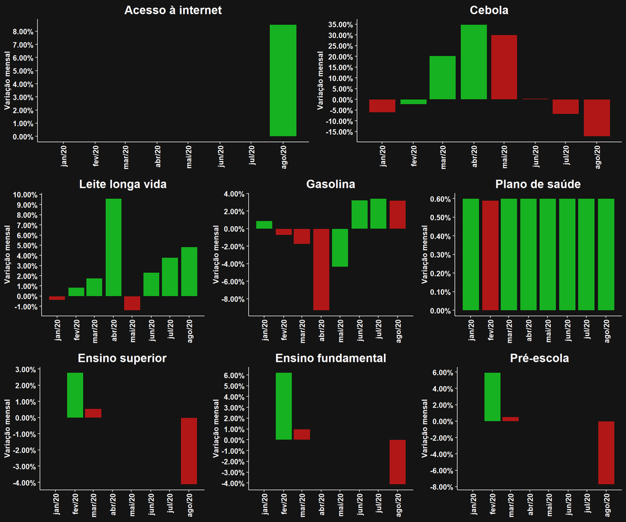

# INPC

O Indíce Nacional de Preços ao Consumidor (INPC) variou 0.36% em agosto, valor superior ao mesmo período do ano anterior quando apresentou uma taxa de 0.12%. Com esse resultado o indíce acumula no ano uma variação positiva de 1.16%, e em 12 meses uma variação positiva de 2.94%.

|  | 08/2019 | 07/2020 | 08/2020 |
| --- | --- | --- | --- |
| Variação mensal | 0.12% | 0.44% | 0.36% |
| Variação acumulada no ano | 2.68% | 0.8% | 1.16% |
| Variação acumulada em 12 meses | 3.28% | 2.69% | 2.94% |

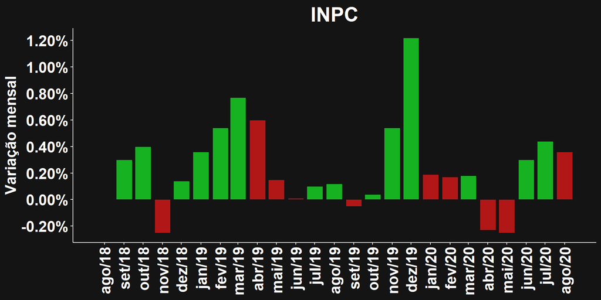

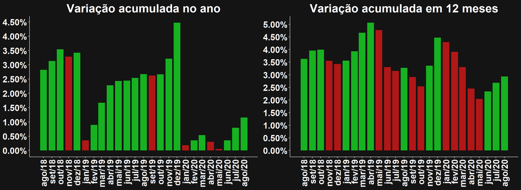

# IGP-M

O Indíce Geral de Preços de Mercado (IGP-M) variou 2.74% em agosto, valor superior ao mesmo período do ano anterior quando apresentou uma taxa de -0.67%. Com esse resultado o indíce acumula no ano uma variação positiva de 9.12%, e em 12 meses uma variação positiva de 13.02%.

|  | 08/2019 | 07/2020 | 08/2020 |
| --- | --- | --- | --- |
| Variação mensal | -0.67% | 2.23% | 2.74% |
| Variação acumulada no ano | 4.09% | 6.21% | 9.12% |
| Variação acumulada em 12 meses | 4.95% | 9.27% | 13.02% |

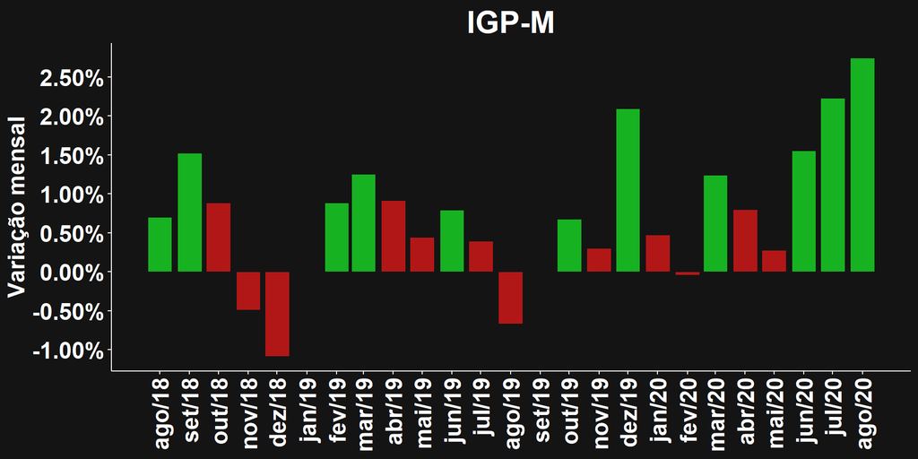

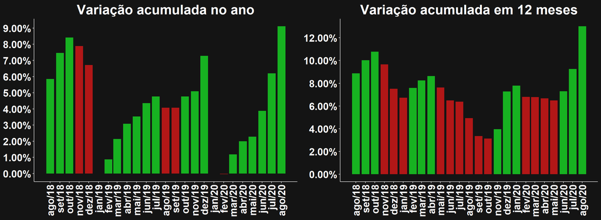

# IGP-DI

O Indíce Geral de Preços - Disponibilidade Interna (IGP-DI) variou 3.87% em agosto, valor superior ao mesmo período do ano anterior quando apresentou uma taxa de -0.51%. Com esse resultado o indíce acumula no ano uma variação positiva de 11.03%, e em 12 meses uma variação positiva de 15.23%.

|  | 08/2019 | 07/2020 | 08/2020 |
| --- | --- | --- | --- |
| Variação mensal | -0.51% | 2.34% | 3.87% |
| Variação acumulada no ano | 3.79% | 6.89% | 11.03% |
| Variação acumulada em 12 meses | 4.32% | 10.37% | 15.23% |

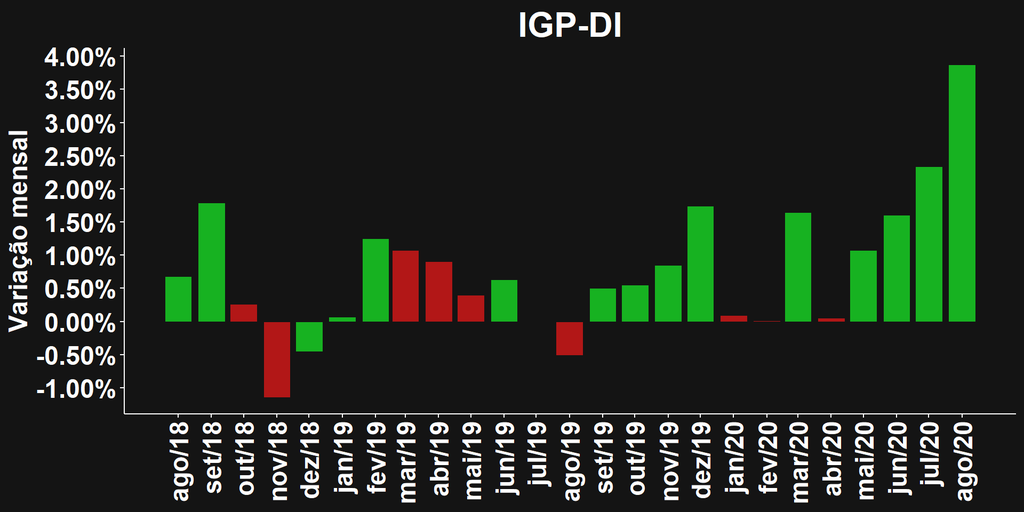

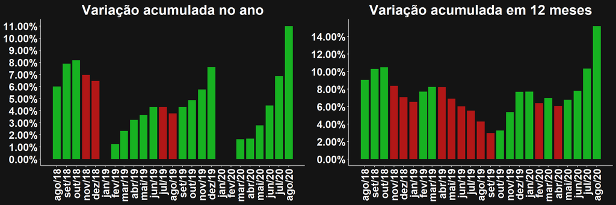

[output not shown]

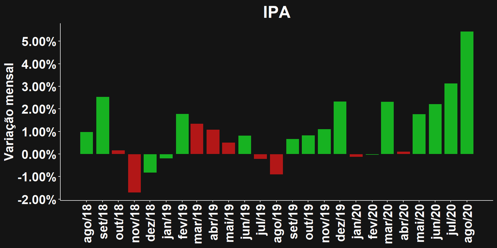

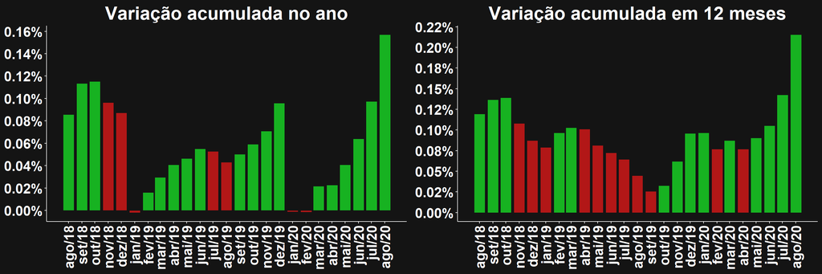

O Indíce de Preços ao Consumidor (IPC), integrante do IGP-DI com peso de 30%, apresentou variação de 0.53% em agosto, valor superior ao mesmo período do ano anterior quando apresentou uma taxa de 0.17%. Com esse resultado o indíce acumula no ano uma variação positiva de 0.99%, e em 12 meses uma variação positiva de 2.77%.

|  | 08/2019 | 07/2020 | 08/2020 |
| --- | --- | --- | --- |
| Variação mensal | 0.17% | 0.49% | 0.53% |
| Variação acumulada no ano | 2.32% | 0.45% | 0.99% |
| Variação acumulada em 12 meses | 3.97% | 2.4% | 2.77% |

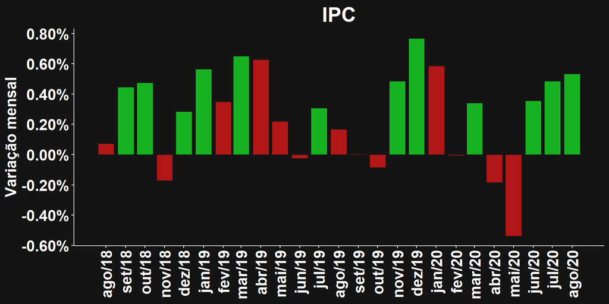

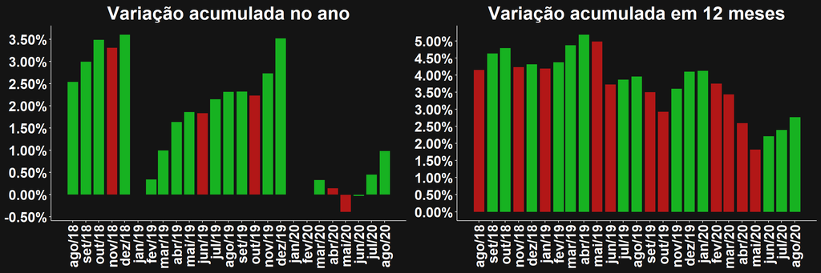

O Indíce Nacional de Custos de Construção (INCC), integrante do IGP-DI com peso de 10%, apresentou variação de 0.72% em agosto, valor superior ao mesmo período do ano anterior quando apresentou uma taxa de 0.42%. Com esse resultado o indíce acumula no ano uma variação positiva de 3.28%, e em 12 meses uma variação positiva de 4.6%.

|  | 08/2019 | 07/2020 | 08/2020 |
| --- | --- | --- | --- |
| Variação mensal | 0.42% | 1.17% | 0.72% |
| Variação acumulada no ano | 2.73% | 2.54% | 3.28% |
| Variação acumulada em 12 meses | 4.11% | 4.29% | 4.6% |

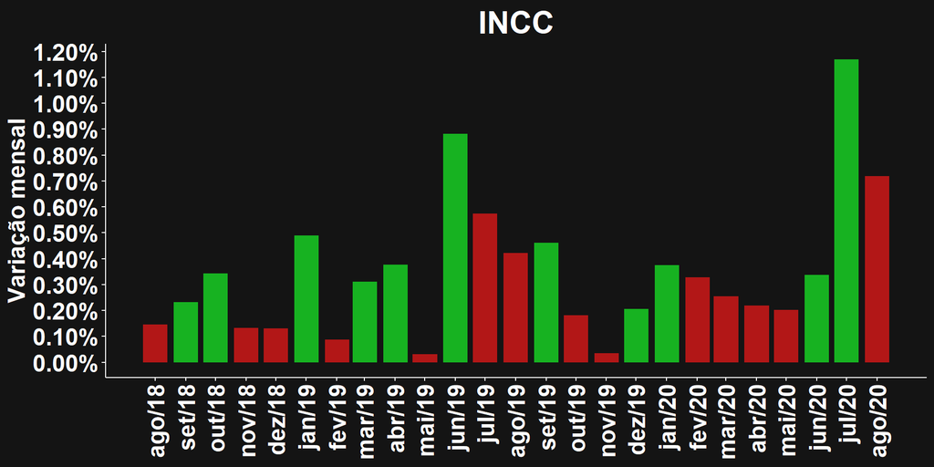

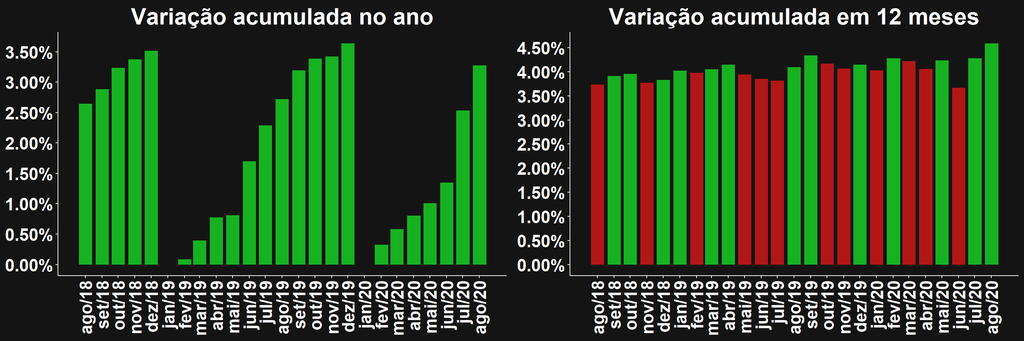

# Estatísticas

As estatísticas descritivas a seguir são feitas com base nos últimos 48 meses, e tem como objetivo possibilitar a avaliação do resultado observado em comparação aos períodos anteriores.

|  | Minimo | 1 Quartil | Mediana | Media | 3 Quartil | Maximo | Desvio Padrão |
| --- | --- | --- | --- | --- | --- | --- | --- |
| IPCA | -0.38% | 0.12% | 0.25% | 0.26% | 0.36% | 1.26% | 0.3% |
| INPC | -0.3% | 0.08% | 0.18% | 0.24% | 0.36% | 1.43% | 0.32% |
| IGP-M | -1.1% | 0.06% | 0.49% | 0.5% | 0.88% | 2.74% | 0.82% |
| IGP-DI | -1.24% | 0.05% | 0.47% | 0.54% | 0.91% | 3.87% | 0.91% |
| IPA | -1.96% | -0.05% | 0.55% | 0.65% | 1.15% | 5.44% | 1.34% |
| IPC | -0.54% | 0.13% | 0.33% | 0.29% | 0.48% | 1.19% | 0.3% |
| INCC | -0.02% | 0.18% | 0.31% | 0.35% | 0.41% | 1.17% | 0.26% |

Levando em consideração o desvio padrão de cada indíce, proporcionalmente os que mais se afastaram da média foram o IGP-DI, o IPA e o IGP-M.

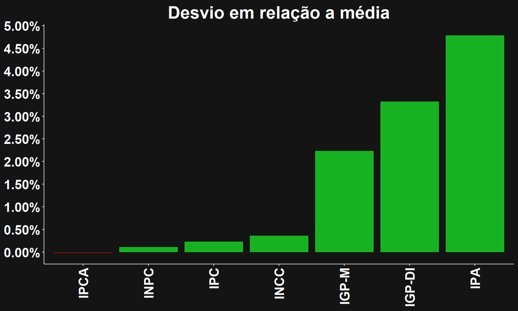

**João Victor Gomes**  
**jvg.santana@gmail.com**  
**[linkedin.com/in/jvictorgomes](https://www.linkedin.com/in/jvictorgomes/)**